# act_report

## Communicating Insights gotten from the tweets_archive data

### questions asked from the data

1. What was the most popular dog stage
2. What was the highest rating for each dog stage
3. was there any relationship between the rating_numerator and any other variable
4. what dog stage was people's favourite and most adorable.

In the twitter archive data set, we had four dog stages given to us, and I was curious to know what dog stage was sent to WeRatesDog twitter page for rating, After querying the data, we found this to be the pupper dog stage. This can be visually displayed below:

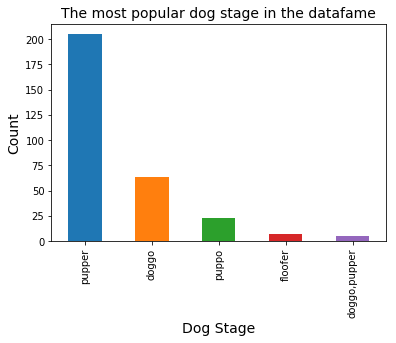

we can see from the above plot that the most popular dog stage is the pupper dog stage

[figure not shown]

```
                                            This Is An Adorable PUPPER
```

The next question I answered was finding out what the highest rating for each dog stage, and we saw the doggo having its highest rating as 14/10, doggo,pupper had 12/10, floofer had 13/10, pupper with a 14/10 and puppo with 14/10

[figure not shown]

```
                          Have a peak at the doggo stage with the highest ratings
```

[figure not shown]

```
                                               Here's our doggo,pupper
```

[output not shown]

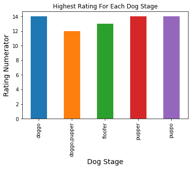

I tried to find out if there was any relationship between rating numerator and the rest of the variables that were present in the data frame to find out if there was any variable present that could tend to lead to an increase in ratings. Guess what there was none unfortunately.

[figure not shown]

Finally for the best part of the analysis, lets check what dog stage was audience most liked picture posted on the WeRateDogs twitter page, I was really curious to know this one, well after my anaysis I got the following results displayed visually below:

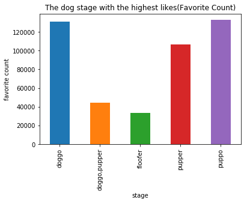

[figure not shown]

Well, there you have it guys, your most adorable puppo dog stage, Thanks for reading.